# Data Sourcing via Web

## Introduction to NLP

```python
import nltk
```

```python
text = "Our greatest fear is not that we are inadequate, but that we are powerful beyond measure. It is our light, not our darkness, that frightens us. We ask ourselves, Who am I to be brilliant,gorgeous, handsome, talented and fabulous? Actually, who are you not to be? You are a child of God. Your playing small does not serve the world. There is nothing enlightened about shrinking so that other people won't feel insecure around you. We were born to make manifest the glory of God within us. It is not just in some; it is in everyone. And, as we let our own light shine, we consciously give other people permission to do the same. As we are liberated from our fear, our presence automatically liberates others."
```

```python
nltk.download('punkt')
```

```
True
```

### Sentence Tokenizer

In this section, I will tokenize the sentences from the poem "Our Greatest Fear" by Marianne Williamson

```python
from nltk.tokenize import sent_tokenize
sent_tk = sent_tokenize(text)
print('Sentence Tokenizing the Text \n')
print(sent_tk)
```

```
Sentence Tokenizing the Text

['Our greatest fear is not that we are inadequate, but that we are powerful beyond measure.', 'It is our light, not our darkness, that frightens us.', 'We ask ourselves, Who am I to be brilliant,gorgeous, handsome, talented and fabulous?', 'Actually, who are you not to be?', 'You are a child of God.…
```

### Word Tokenizer

In this section, I will tokenize the words from the poem "Our Greatest Fear" by Marianne Williamson.

```python
from nltk.tokenize import word_tokenize
word_tk = word_tokenize(text)
print('Word Tokenizing the Text \n')
print(word_tk)
```

```
Word Tokenizing the Text

['Our', 'greatest', 'fear', 'is', 'not', 'that', 'we', 'are', 'inadequate', ',', 'but', 'that', 'we', 'are', 'powerful', 'beyond', 'measure', '.', 'It', 'is', 'our', 'light', ',', 'not', 'our', 'darkness', ',', 'that', 'frightens', 'us', '.', 'We', 'ask', 'ourselves', ',', 'Who', 'am', 'I', 'to', 'b…
```

### Removing stop words

```python
nltk.download('stopwords')
```

```
True
```

Here I will show, all the Stop Words in the English language. Stop Words are extremely common words that add little meaning to a body of text and create noise.

```python
from nltk.corpus import stopwords

sw =set(stopwords.words('English'))

print('Stop Words in English Language')
print(sw)
```

```
Stop Words in English Language
{'into', "hasn't", "doesn't", 'shan', "isn't", 'what', 'such', 've', "she's", 'these', 'below', 'my', 'and', 'he', 'were', "you'd", "you'll", 'hers', 'wouldn', 'themselves', 'few', 'to', 'here', 'having', 'their', 'a', 'other', 'but', 'there', 'had', 'up', 'do', 'weren', 'you', 'very', 'it', 'doesn'…
```

Now, I will remove the Stop Words from the poem. Some advantages of this are that it will remove the noise and reduce the size of the textual data to be analyzed.

```python
filtered_words = [w for w in word_tk if not w in sw]

print('The text After Removing Stop Words')
print(filtered_words)
```

```
The text After Removing Stop Words
['Our', 'greatest', 'fear', 'inadequate', ',', 'powerful', 'beyond', 'measure', '.', 'It', 'light', ',', 'darkness', ',', 'frightens', 'us', '.', 'We', 'ask', ',', 'Who', 'I', 'brilliant', ',', 'gorgeous', ',', 'handsome', ',', 'talented', 'fabulous', '?', 'Actually', ',', '?', 'You', 'child', 'God'…
```

### Stemming

In this section will I will conduct stemming on the poem words. This will reduce the size fo the text by converting words to their root word.

```python
from nltk.stem import PorterStemmer
from nltk.tokenize import sent_tokenize, word_tokenize
port_stem =PorterStemmer()
```

```python
stemmed_words = []

for w in filtered_words:
    stemmed_words.append(port_stem.stem(w))

print('Filtered Sentence: \n', filtered_words, '\n')
print('Stemmed Sentence: \n', stemmed_words)
```

```
Filtered Sentence:
 ['Our', 'greatest', 'fear', 'inadequate', ',', 'powerful', 'beyond', 'measure', '.', 'It', 'light', ',', 'darkness', ',', 'frightens', 'us', '.', 'We', 'ask', ',', 'Who', 'I', 'brilliant', ',', 'gorgeous', ',', 'handsome', ',', 'talented', 'fabulous', '?', 'Actually', ',', '?', 'You', 'child', 'God…

Stemmed Sentence:
 ['our', 'greatest', 'fear', 'inadequ', ',', 'power', 'beyond', 'measur', '.', 'It', 'light', ',', 'dark', ',', 'frighten', 'us', '.', 'We', 'ask', ',', 'who', 'I', 'brilliant', ',', 'gorgeou', ',', 'handsom', ',', 'talent', 'fabul', '?', 'actual', ',', '?', 'you', 'child', 'god', '.', 'your', 'play…
```

# Lemmatizing

In this section I will lemmatize the words. This will reduce each word into its base word.

```python
nltk.download('wordnet')
```

```
True
```

```python
from nltk.stem.wordnet import WordNetLemmatizer

lemm = WordNetLemmatizer()

from nltk.stem.porter import PorterStemmer
stem = PorterStemmer()

lemm_words = []

for i in range(len(filtered_words)):
    lemm_words.append(lem.lemmatize(filtered_words[i]))

print(lemm_words)
```

[output not shown]

### Parts of Speech Tagging

In this part, I will conduct part of speech tagging. This will identify the part of speech of a given word in a sentece and context.

```python
nltk.download('averaged_perceptron_tagger')
```

```
True
```

```python
from nltk import pos_tag
pos_tagged_words = pos_tag(word_tk)

print(pos_tagged_words)
```

```
[('Our', 'PRP$'), ('greatest', 'JJS'), ('fear', 'NN'), ('is', 'VBZ'), ('not', 'RB'), ('that', 'IN'), ('we', 'PRP'), ('are', 'VBP'), ('inadequate', 'JJ'), (',', ','), ('but', 'CC'), ('that', 'IN'), ('we', 'PRP'), ('are', 'VBP'), ('powerful', 'JJ'), ('beyond', 'IN'), ('measure', 'NN'), ('.', '.'), ('I…
```

### Frequency Distribution Plots

Next, I will plot the frequency distribution of the words in the poem. This can be useful when conducting sentiment analysis.

```python
from nltk.probability import FreqDist
fd = FreqDist(word_tk)
print(fd)
```

```
<FreqDist with 93 samples and 152 outcomes>
```

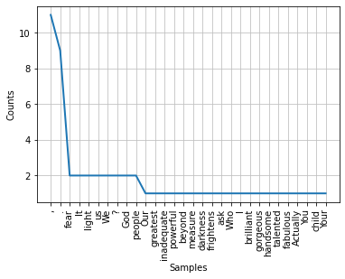

```python
import matplotlib.pyplot as plt
fd.plot(30, cumulative= False)
plt.show()
```

```
<FreqDist with 41 samples and 387 outcomes>
```

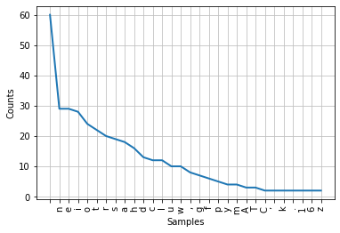

```python
# check frequency distribution of the alphabet used in the text

fd_alpha = FreqDist(text)
print(fd_alpha)
fd_alpha.plot(30, cumulative=False)
plt.show()
```